# Hôtel à insectes géant ECONEX - 119 x 79 x 39 cm

[figure not shown]

471,24 €

- Prix dégressifs

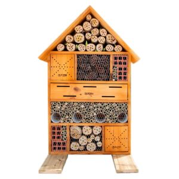

Photo(s) non contractuelle(s)

# Hôtel à insectes géant ECONEX - 119 x 79 x 39 cm

## Abris et nichoirs ECONEX

Ce refuge/hôtel à insectes en bois de pin de 20 mm d'épaisseur offre une solution robuste et esthétique pour favoriser la biodiversité. Avec 11 espaces, dont 10 fermés à l'arrière, il propose une variété de matériaux soigneusement sélectionnés pour créer des habitats idéaux pour l'hibernation et la reproduction d'une multitude d'insectes. La sécurité est assurée par un grillage dans les espaces ouverts, et les deux espaces praticables offrent des habitats sombres accessibles par des perforations, favorisant ainsi une vie sauvage diversifiée.  
En résumé, cet hôtel à insectes allie durabilité, esthétique et fonctionnalité pour enrichir votre environnement extérieur.  
Vendu à l'unité.

En savoir plus

Référence : ECONTA325

Voir le tableau de prix [Vous avez un doute ? Demandez un renseignement sur le produit](https://agrifournitures.fr/nous-contacter?product=77033)

- Paiement sécurisé

[figure not shown]

Tableau des prix

|  |  | Prix dégressifs |  |  |  |
| --- | --- | --- | --- | --- | --- |
| Produit | Prix unitaire | A partir de 3 | A partir de 5 | A partir de 10 | Commandez |
| Produit **Référence** - ECONTA325 Délai - Livraison 1 à 4 semaines | Prix unitaire 392,70 € HT 471,24 € TTC | Prix dégressifs A partir de 3 365,21 € HT 438,25 € TTC 471,24 € TTC -7 % | A partir de 5 353,43 € HT 424,12 € TTC 471,24 € TTC -10 % | A partir de 10 333,79 € HT 400,55 € TTC 471,24 € TTC -15 % | Commandez Quantité Total : **392,70 € HT** |

[Tous les produits de la marque ECONEX](https://agrifournitures.fr/609_econex) Partager la fiche par mail  
Imprimer la fiche

- Description
- Caractéristiques
- Notices et documents
- Livraison spéciale

Description Haut de la page

Origine Europe

### Hôtel à insectes géant ECONEX - 119 x 79 x 39 cm

### DESCRIPTION

Refuge/hôtel à insectes composé d'une structure en bois de pin à rainure et languette, de 20 mm d'épaisseur, résistant aux intempéries et traité avec lasure.  
Il est composé de 11 espaces, dont 10 fermés à l'arrière, qui contiennent différents matériaux offrant des habitats abris pour l'hibernation et la reproduction de nombreuses espèces d'insectes et d'arachnides.  
Les matériaux d'abri comprennent des pommes de pin ouvertes, des roseaux coupés, de l'herbe sèche, des fragments de briques en terre cuite, des sections de brindilles de fruits et des sections de branches trouées.  
Les matériaux contenus dans les espaces ouverts sont sécurisés par du grillage, sauf dans l'espace supérieur, qui est grillagé tant à l'avant qu'à l'arrière, et auquel sont fixées les bûches.  
Il dispose de deux espaces fermés et praticables, l'un rectangulaire et l'autre carré, qui génèrent des habitats sombres remplis de matière végétale sèche, accessibles aux insectes par une série de perforations de différentes tailles.  
L'ensemble de la structure est renforcé par des vis.  
Le produit est fourni avec deux supports pour le placement.

### DIMENSIONS

Côtés et toit de 20 mm d'épaisseur.  
Hauteur Max : 119 cm / Largeur : 79 cm / Profondeur : 39 cm.

### POIDS

60 KG

### PRINCIPALES BENÉFICES A METTRE EN PLACE UN HOTEL A INSECTES

Le refuge à insectes est un outil de conservation de l'entomofaune local qui entraîne une augmentation de la biodiversité.  
La colonisation par les insectes favorise la pollinisation de nos plantes et cultures et certains insectes jouent également un rôle important dans la lutte biologique contre les ravageurs.  
Il convient également de souligner l’importance des refuges à insectes pour l’éducation environnementale.  
C’est un abri d'hibernation et, dans certains cas, d'élevage de nombreuses espèces d'insectes et d'arachnides qui se nourrissent d'autres insectes nuisibles dans les parcs et jardins privés et publics.  
Les insectes qui utilisent le plus souvent ces abris sont d'importants pollinisateurs comme les bourdons et les abeilles solitaires, des parasitoïdes d'autres insectes comme les ichneumonidés, les sphécidés et les pompilidés, ainsi que des prédateurs comme les chrysopes et des détritivores comme les perce-oreilles.

### INSTALLATION ET SURVEILLANCE DES REFUGES À INSECTES

Les refuges doivent être situés dans des zones ensoleillées et peu exposées à la pluie.  
Ils doivent être situés à proximité d’une végétation contenant des espèces sauvages, une floraison abondante et des espaces ouverts avec de la terre disponible pour établir des nids pour les espèces hivernantes.  
La disponibilité d'eau à proximité encouragera également l'utilisation du refuge par un plus grand nombre d'espèces.

Caractéristiques Haut de la page

| Catégorie de produit | Élevage & Alim - Matériel d'élevage |
| --- | --- |
| Espèce ciblée | Insectes auxiliaires, pollinisateurs |

Notices et documents Haut de la page

[Fiche technique : Hôtel à insectes géant ECONEX](https://agrifournitures.fr/index.php?controller=attachment&id_attachment=6624)

Livraison spéciale Haut de la page

#### Produit lourd / encombrant

Vous serez très probablement livré en camion semi-remorque. L’accès au lieu de dépose doit donc être praticable pour un tel véhicule et il vous faut également prévoir un moyen de déchargement (tracteur à fourches, engin de manutention…). Dans certains cas, il peut arriver que nous puissions vous livrer avec hayon mais cela n’est pas garanti. Si vous n’êtes pas équipé et que le déchargement nécessite un hayon, celui-ci pourra vous être facturé en supplément.

**Dans tous les cas – Information très importante**  
Le camion s’approchera le plus possible de votre domicile si le code de la route et la législation le permettent : par exemple, en ville des rue sont interdites aux poids lourds et/ou les livraisons peuvent ne pas être autorisés. Le chauffeur vous donnera donc rendez-vous au lieu le plus proche auquel il sera autorisé.  
**Attention : le bon accès à votre lieu de livraison est aussi très important**, il doit être apte à recevoir le camion, le chauffeur peut refuser de s’en rapprocher s’il s’agit d’un chemin de terre, si le revêtement est endommagé, s’il y a de la boue, de l’eau, de la neige etc. Votre accès doit être carrossable.  
Attention : il n’est pas prévu que le chauffeur vous déplace ensuite la marchandise dans le lieu de votre choix, mais si vous lui demandez gentiment et avec un sourire tout est possible !

Voir les détails des conditions de livraison dans [nos conditions générales de vente](https://agrifournitures.fr/content/3-conditions-generales-vente#art9).

En cas de doute concernant l’organisation de votre transport, contactez nous par e-mail à contact@agrifournitures.fr

## Produits dans la même catégorie

[figure not shown]

### Abri de prairie chevaux en bois simple pente larg. 3 m x prof. 4 m...

A partir de 2 005,69 € HT 2 406,83 € TTC

[figure not shown]

Prix dégressifs

### Enclos coulissant pour niche SUPERSTAR La Buvette

1 319,00 € HT 1 582,80 € TTC

[figure not shown]

Prix dégressifs

### Case à veau petit modèle Kerbl

725,37 € HT 870,44 € TTC

[figure not shown]

### Extension pour abri de prairie chevaux en bois simple pente prof. 4...

A partir de 1 425,64 € HT 1 710,77 € TTC

[figure not shown]

- Promo !

Soldes -20% Nouveauté

### Niche individuelle en PEHD pour veau jusqu'à 8 semaines MIDDLESTAR...

438,80 € HT 526,56 € TTC 658,20 €TTC

[figure not shown]

Nouveauté Prix dégressifs

### Enclos basculant pour niche à veau La Buvette

279,00 € HT 334,80 € TTC

[figure not shown]

Nouveauté

### Toit pour case à veau petit modèle Kerbl

219,59 € HT 263,51 € TTC

[figure not shown]

Nouveauté

### Grille de sol en PRV pour case à veau grand modèle (deux pièces) Kerbl

197,89 € HT 237,47 € TTC

[figure not shown]

- Prix réduit

Promo -7%

[figure not shown]

### Niche à veau CalfHouse Master Plus Kerbl, enclos léger ou lourd

A partir de 621,43 € HT 745,71 € TTC 801,84 €TTC

[figure not shown]

- Promo !

Soldes -20% Nouveauté

### Désinfectant plus fraicheur verte Saniterpen 5 L

A partir de 31,99 € HT 38,39 € TTC 47,99 €TTC

[figure not shown]

Nouveauté Prix dégressifs

### Capot d'accès latéral pour niche à veau La Buvette

96,50 € HT 115,80 € TTC

[figure not shown]

Nouveauté

### Panneau en PVC pour case à veau pour façade arrière Kerbl

16,49 € HT 19,79 € TTC

[figure not shown]

[figure not shown]

Prix dégressifs

[figure not shown]

Prix dégressifs

[figure not shown]

[figure not shown]

- Promo !

Soldes -20% Nouveauté

[figure not shown]

Nouveauté Prix dégressifs

[figure not shown]

Nouveauté

[figure not shown]

Nouveauté

[figure not shown]

- Prix réduit

Promo -7%

[figure not shown]

[figure not shown]

- Promo !

Soldes -20% Nouveauté

[figure not shown]

Nouveauté Prix dégressifs

[figure not shown]

Nouveauté

[figure not shown]

[figure not shown]

Prix dégressifs

[figure not shown]

Prix dégressifs

[figure not shown]

[figure not shown]

- Promo !

Soldes -20% Nouveauté

[figure not shown]

Nouveauté Prix dégressifs